# ANN_Project_Univariate_Feed_Forward

Loading the Libraries & Data

```python
import warnings
warnings.filterwarnings('ignore')

import numpy as np
import pandas as pd
import matplotlib.pyplot as plt
from scipy import stats
import seaborn as sb
from sklearn.model_selection import train_test_split
from sklearn.preprocessing import MinMaxScaler
import seaborn as sb

import torch
import torch.nn as nn
import torch.utils.data as td


jena_df = pd.read_csv("jena_climate_2009_2016.csv")

#renaming the columns
jena_df = jena_df.rename(columns={"Date Time": "DateTime", "p (mbar)": "Pressure", "T (degC)": "TempCelsius", "Tpot (K)": "TempKelvin", "Tdew (degC)": "TempDewCelsius",
                        "rh (%)": "RelativeHumidity", "VPmax (mbar)": "SatVapourPress", "VPact (mbar)": "VapourPressure", "VPdef (mbar)": "VapPressDeficit",
                        "sh (g/kg)": "SpecificHumidity", "H2OC (mmol/mol)": "WaterVapConc", "rho (g/m**3)": "AirDensity", "wv (m/s)": "WindSpeed",
                        "max. wv (m/s)": "MaxWindSpeed", "wd (deg)": "WindDirDegrees"})
```

**Data Preprocessing**

All these steps are explained in the data cleaning sheet and combined here in one cell for fast processing of the data.

```python
#taking only the hourly values
jena_df = jena_df[5::6]

#removing incorrect values
jena_df['WindSpeed'].replace(-9999, 0, inplace = True)
jena_df['MaxWindSpeed'].replace(-9999, 0, inplace = True)

#treating outliers
def out_treat(var):
    Q1 = np.quantile(var.dropna(), 0.25)
    Q3 = np.quantile(var.dropna(), 0.75)
    IQR = Q3-Q1
    LC = Q1 - (3 * IQR)
    UC = Q3 + (3 * IQR)
    var[var > UC] = UC
    var[var < LC] = LC
    return (var)
jena_df = jena_df[~jena_df.index.duplicated()]

jena_df.Pressure = out_treat(jena_df.Pressure)
jena_df.SatVapourPress = out_treat(jena_df.SatVapourPress)
jena_df.VapPressDeficit = out_treat(jena_df.VapPressDeficit)
jena_df.AirDensity = out_treat(jena_df.AirDensity)

#deriving the wind vector components
wv = jena_df.pop('WindSpeed')
max_wv = jena_df.pop('MaxWindSpeed')
# Convert to radians.
wd_rad = jena_df.pop('WindDirDegrees')*np.pi / 180
# Calculate the wind x and y components.
jena_df['Wx'] = wv*np.cos(wd_rad)
jena_df['Wy'] = wv*np.sin(wd_rad)
# Calculate the max wind x and y components.
jena_df['max Wx'] = max_wv*np.cos(wd_rad)
jena_df['max Wy'] = max_wv*np.sin(wd_rad)

#drop variables that have redundant data (multicollinearity)
jena_df.drop(['TempCelsius'],axis=1,inplace=True)
jena_df.drop(['VapourPressure'],axis=1,inplace=True)
jena_df.drop(['WaterVapConc'],axis=1,inplace=True)

#setting datetime as the index
jena_df.set_index('DateTime',inplace=True, drop=True)

#Seperating the independent and dependent data
data = jena_df[["TempKelvin"]]

#Splitting the data for training and testing
test_size = round(len(data) * 0.2)
traindf = data[:-test_size]
testdf = data[-test_size:]

#Scaling - Fit and Transform TRAIN data
min_max_scaler = MinMaxScaler()
trainsc = min_max_scaler.fit_transform(traindf)
testsc = min_max_scaler.transform(testdf)

#Converting back to Pandas dataframe
traindf = pd.DataFrame(trainsc, columns = traindf.columns, index = traindf.index)
testdf = pd.DataFrame(testsc, columns = testdf.columns, index = testdf.index)

#concatenating train and test data
data = traindf.append(testdf)
```

**Creating Sequences & Transforming to tensors**

Step by Step Explanation:

1] Creating sequences of 168 lags (1 week of historical data)taken for all the data.

2] Splitting the data into train and test section as decided before.

3] Slicing the numpy arrays from both train and test data to create sequences train_x, train_y, test_x and test_y. (Keeping the mind the offset decided: 24 - predicting temperature after 24 hours)

4] Transforming the numpy arrays into PyTorch tensors.

5] Joining input sequences tensors with output sequences tensors.

6] Defining batch size for train and test data and creating data loader files for both training and testing.

```python
#defining a funtion to create input&output sequences
def split_data(inputDF, lookback, offset):
    data_raw = inputDF.to_numpy()
    data = []

    # create all possible sequences of length seq_len
    for index in range(len(data_raw) - lookback):
        data.append(data_raw[index: index + lookback])

    #taking out the same set for training data as we did before
    data = np.array(data);
    test_set_size = int(np.round(0.2*data.shape[0]));
    train_set_size = data.shape[0] - (test_set_size);

    #slicing numpy arrays to get desired sequences
    x_train = data[:train_set_size,:,:]
    y_train = data[lookback + offset:train_set_size+lookback+offset, 0, :]

    x_test = data[train_set_size:- (offset+lookback), :, :]
    y_test = data[train_set_size + lookback + offset:, 0, :]

    return [x_train, y_train, x_test, y_test]


lookback = 168 # choose sequence length
offset = 23 #target value selected with an offset (predict the temperature for tomorrow)
x_train, y_train, x_test, y_test = split_data(data, lookback, offset)

#creating torch tensors from numpy arrays
x_train = torch.from_numpy(x_train).type(torch.Tensor)
x_test = torch.from_numpy(x_test).type(torch.Tensor)
y_train = torch.from_numpy(y_train).type(torch.Tensor)
y_test = torch.from_numpy(y_test).type(torch.Tensor)

#creating 3D data loaders (batch size, lookbacks, input features)
train_tensor = torch.utils.data.TensorDataset(x_train, y_train)
train_loader = torch.utils.data.DataLoader(dataset = train_tensor, batch_size = np.math.ceil(len(x_train)/10), shuffle = False)

test_tensor = torch.utils.data.TensorDataset(x_test, y_test)
test_loader = torch.utils.data.DataLoader(dataset = test_tensor, batch_size = len(x_test),shuffle = False)
```

Checking if GPU available, then using it!

```python
device = torch.device('cuda' if torch.cuda.is_available() else 'cpu')
print("SELECTED DEVICE: ", device)
torch.cuda.empty_cache()
host = torch.device('cpu')
print("HOST DEVICE: ", host)
```

```
SELECTED DEVICE:  cuda
HOST DEVICE:  cpu
```

# Feed Forward

Network Structure

```python
class FF(nn.Module):

  def __init__(self, input_dim, first_hidden_dim, second_hidden_dim, output_dim):
    super(FF, self).__init__()

    self.hidden1 = nn.Linear(input_dim, first_hidden_dim)
    self.sigmoid = nn.Sigmoid()
    self.hidden2 = nn.Linear(first_hidden_dim, second_hidden_dim)
    self.output = nn.Linear(second_hidden_dim, 1)

  def forward(self, every_batch):

    every_batch = self.hidden1(every_batch)
    every_batch = self.sigmoid(every_batch)
    every_batch = self.hidden2(every_batch)
    every_batch = self.sigmoid(every_batch)
    every_batch = self.output(every_batch)

    return every_batch
```

Defining the Model

Tuning the Model: Since, we are taking the hourly data from past 7 days, the input dimension of the first hidden layer should be 168 (24 * 7). We are prediting just one value i.e. the temperature after 24 hours. Hence, the output dimension of the last layer should be 1.

Hidden layers: We tried the network structure with 1, 2, and 3 hidden layers. It was observed that with sufficient number of hidden nodes 2 hidden layer network is sufficient to train over this dataset.

Hidden layers dimensions: We experimented the hidden nodes with different powers of 2. Since, the input nodes are 168 and the output node is 1, we tried gradually reducing the size of the structure from 168 t 1.

```python
input_dim = 168 #input lags
first_hidden_dim = 64 #no. of units in firt hidden layer
second_hidden_dim = 16 #no. of hidden units in second hidden layer
output_dim = 1 #one value to predict
num_epochs = 40 #no. of epochs

model = FF(input_dim=input_dim, first_hidden_dim=first_hidden_dim, second_hidden_dim = second_hidden_dim,
           output_dim=output_dim)
model.to(device)

criterion = torch.nn.MSELoss(reduction='mean') #calculating the loss
optimiser = torch.optim.Adam(model.parameters(), lr=0.01) #adam optimiser with learning rate of 0.01
```

Running Model over Epochs

```python
#defining a function for test data
def validation(model):
    with torch.no_grad():
        for input, target in test_loader:
            input = input.view(input.size(0), input.size(1)) #chaning the shape from 3D to 2D
            y_test_pred = model(input.to(device))
            test_loss = criterion(y_test_pred, target.to(device))
    return test_loss.item(), y_test_pred

#training over the number of epochs
import time #to measure the time taken by model to run
training_losses = np.zeros(num_epochs)
testing_losses = np.zeros(num_epochs)
start_time = time.time()
for t in range(num_epochs):
    for input, target in train_loader:
        input = input.view(input.size(0), input.size(1)) #chaning the shape from 3D to 2D
        y_train_pred = model(input.to(device)) #predicted values of train data
        train_loss = criterion(y_train_pred, target.to(device)) #calculate train loss

        optimiser.zero_grad() #making the gradients zero
        train_loss.backward() #backpropogating through the network by changing weights
        optimiser.step()

    training_losses[t] = train_loss.item()
    testing_losses[t] = validation(model)[0]

    print("Epoch ", t, "Train MSE: ", train_loss.item(), "Test MSE: ", validation(model)[0])


training_time = time.time()-start_time
print("Training time: {}".format(training_time))
```

```
Epoch  0 Train MSE:  0.040143560618162155 Test MSE:  0.02002265863120556
Epoch  1 Train MSE:  0.011289527639746666 Test MSE:  0.02623777464032173
Epoch  2 Train MSE:  0.02201671339571476 Test MSE:  0.019172241911292076
Epoch  3 Train MSE:  0.010501407086849213 Test MSE:  0.02311078831553459
Epoch  4 Train MSE:  0.015268843621015549 Test MSE:  0.018769538030028343
Epoch  5 Train MSE:  0.011576992459595203 Test MSE:  0.019910119473934174
Epoch  6 Train MSE:  0.012965051457285881 Test MSE:  0.01868431456387043
Epoch  7 Train MSE:  0.011837230995297432 Test MSE:  0.018499251455068588
Epoch  8 Train MSE:  0.01188365276902914 Test MSE:  0.017839301377534866
Epoch  9 Train MSE:  0.01187871117144823 Test MSE:  0.01707254908978939
Epoch  10 Train MSE:  0.011406906880438328 Test MSE:  0.01651453971862793
Epoch  11 Train MSE:  0.011294366791844368 Test MSE:  0.015884676948189735
Epoch  12 Train MSE:  0.011573778465390205 Test MSE:  0.015283659100532532
Epoch  13 Train MSE:  0.011906917206943035 Test MSE:  0.014856606721878052
Epoch  14 Train MSE:  0.012015030719339848 Test MSE:  0.014526210725307465
Epoch  15 Train MSE:  0.012104427441954613 Test MSE:  0.014189978130161762
Epoch  16 Train MSE:  0.01253525074571371 Test MSE:  0.013870705850422382
Epoch  17 Train MSE:  0.013375766575336456 Test MSE:  0.013639809563755989
Epoch  18 Train MSE:  0.014339147135615349 Test MSE:  0.013487711548805237
Epoch  19 Train MSE:  0.015104182064533234 Test MSE:  0.01334624644368887
Epoch  20 Train MSE:  0.015624179504811764 Test MSE:  0.013143714517354965
Epoch  21 Train MSE:  0.015990853309631348 Test MSE:  0.01282550860196352
Epoch  22 Train MSE:  0.01614667847752571 Test MSE:  0.012347107753157616
Epoch  23 Train MSE:  0.015833714976906776 Test MSE:  0.011656530201435089
Epoch  24 Train MSE:  0.014657714404165745 Test MSE:  0.0107339546084404
Epoch  25 Train MSE:  0.012102310545742512 Test MSE:  0.009857372380793095
Epoch  26 Train MSE:  0.008279116824269295 Test MSE:  0.010053504258394241
Epoch  27 Train MSE:  0.005602381192147732 Test MSE:  0.010489336214959621
Epoch  28 Train MSE:  0.005701835732907057 Test MSE:  0.008254322223365307
Epoch  29 Train MSE:  0.0061558750458061695 Test MSE:  0.007789930794388056
Epoch  30 Train MSE:  0.005441743414849043 Test MSE:  0.00718303956091404
Epoch  31 Train MSE:  0.005277876276522875 Test MSE:  0.006937424652278423
Epoch  32 Train MSE:  0.0052133165299892426 Test MSE:  0.006340613588690758
Epoch  33 Train MSE:  0.004877268802374601 Test MSE:  0.006002176087349653
Epoch  34 Train MSE:  0.004870081786066294 Test MSE:  0.005664617754518986
Epoch  35 Train MSE:  0.004910282790660858 Test MSE:  0.005407439544796944
Epoch  36 Train MSE:  0.004984293133020401 Test MSE:  0.00524181267246604
Epoch  37 Train MSE:  0.005149275995790958 Test MSE:  0.00512960460036993
Epoch  38 Train MSE:  0.0054269288666546345 Test MSE:  0.005031256470829248
Epoch  39 Train MSE:  0.005779278930276632 Test MSE:  0.004912258591502905
Training time: 29.475056886672974
```

```python
from IPython.display import Markdown, display
def printmd(string):
    display(Markdown(string))
printmd('#Points to Note:')
printmd(f"##1. Epochs Taken: {num_epochs}")
printmd(f"##2. Time Taken: {round(training_time)} seconds")
printmd(f"##3. Final MSE (test data): {round(testing_losses[num_epochs-1], 6)}")
```

Points to Note:

1. Epochs Taken: 40

2. Time Taken: 29 seconds

3. Final MSE (test data): 0.004912

Making predictions over test data

```python
#predicted test data values
predict = pd.DataFrame(min_max_scaler.inverse_transform(validation(model)[1].to(host).detach().numpy()))
predict = predict.rename(columns={0: "Predicted"})
#original test data labels
original = pd.DataFrame(min_max_scaler.inverse_transform(y_test.detach().numpy()))
original = original.rename(columns={0: "Original"})

result = pd.concat([original, predict], axis=1, join='inner')
result.head(5)
```

|  | Original | Predicted |
| --- | --- | --- |
| 0 | 281.479980 | 283.439514 |
| 1 | 281.529999 | 283.622803 |
| 2 | 281.750000 | 284.275238 |
| 3 | 282.489990 | 285.223419 |
| 4 | 283.880005 | 286.230743 |

Plotting training and testing losses

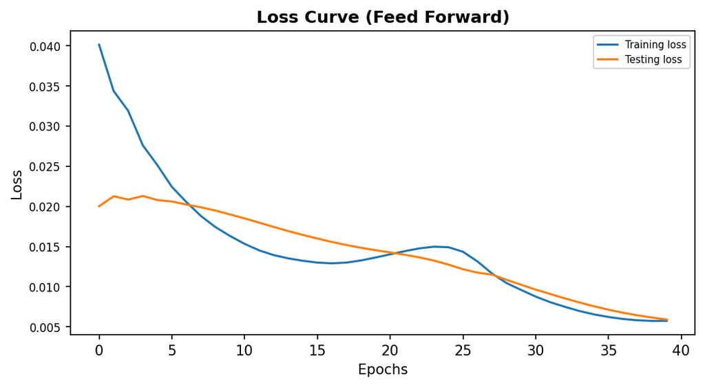

```python
def smooth_curve(points, factor=0.8): #this function will make our plots more smooth
	smoothed_points = []
	for point in points:
		if smoothed_points:
			previous = smoothed_points[-1]
			smoothed_points.append(previous*factor+point*(1-factor))
		else:
			smoothed_points.append(point)
	return smoothed_points


# plotting the training and validation loss
plt.figure(figsize=(8,4),dpi=150)
plt.plot(smooth_curve(training_losses), label='Training loss')
plt.plot(smooth_curve(testing_losses), label='Testing loss')
plt.title('Loss Curve (Feed Forward)',fontweight='bold')
plt.xlabel('Epochs', fontsize=10)
plt.ylabel('Loss', fontsize=10)
plt.yticks(size=8)
plt.legend(prop={'size': 7})
plt.show()
```

Plotting predicted values against actual values

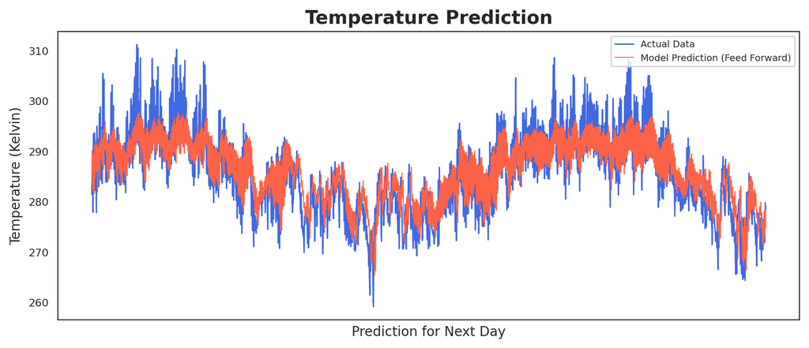

```python
plt.figure(figsize = (10,4), dpi=200)
sb.set_style("white")

sb.lineplot(x = original.index, y = original["Original"], label="Actual Data", color='royalblue',linewidth=1)
sb.lineplot(x = predict.index, y = predict["Predicted"], label="Model Prediction (Feed Forward)", color='tomato',linewidth=0.7)
plt.title('Temperature Prediction', size = 14, fontweight='bold')
plt.xlabel("Prediction for Next Day", size = 10)
plt.ylabel("Temperature (Kelvin)", size = 10)
plt.xticks(ticks=[])
plt.yticks(size=8)
plt.legend(loc="upper right", prop={'size': 7})
plt.show()
```